# Genomic Drivers of Survival in Luminal A and B Breast Cancer

# Coversheet

[figure not shown]

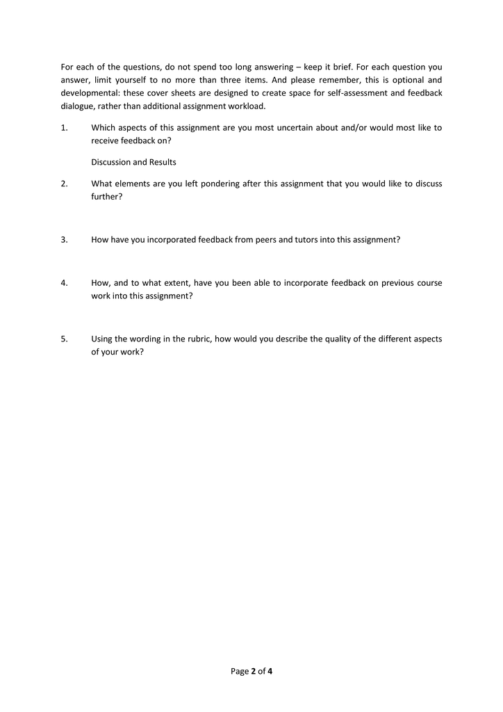

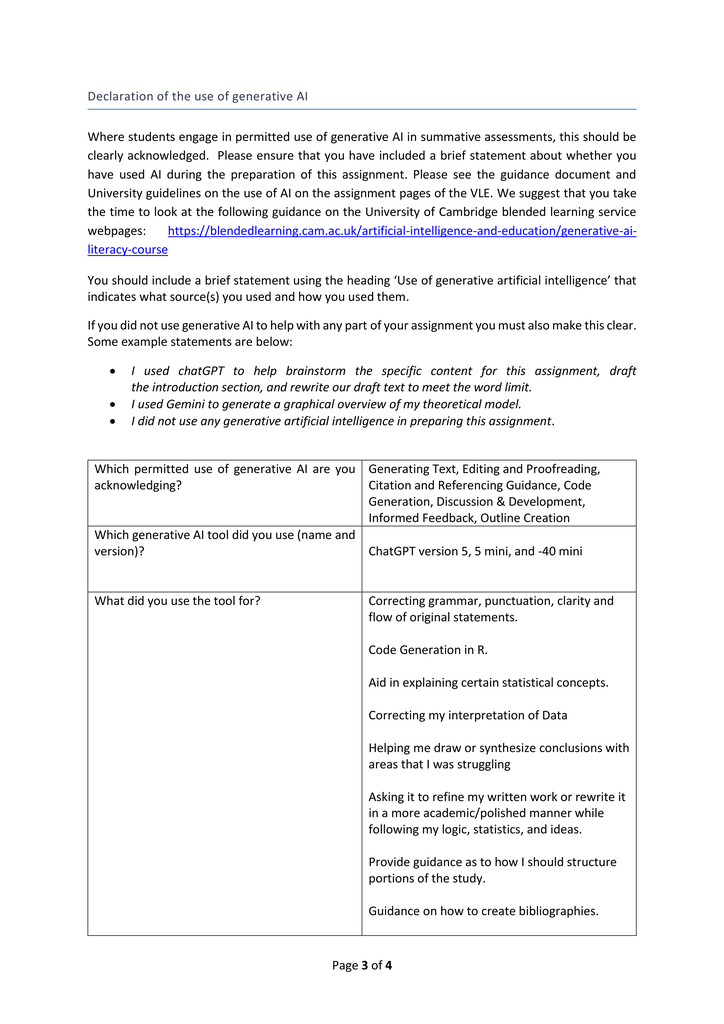

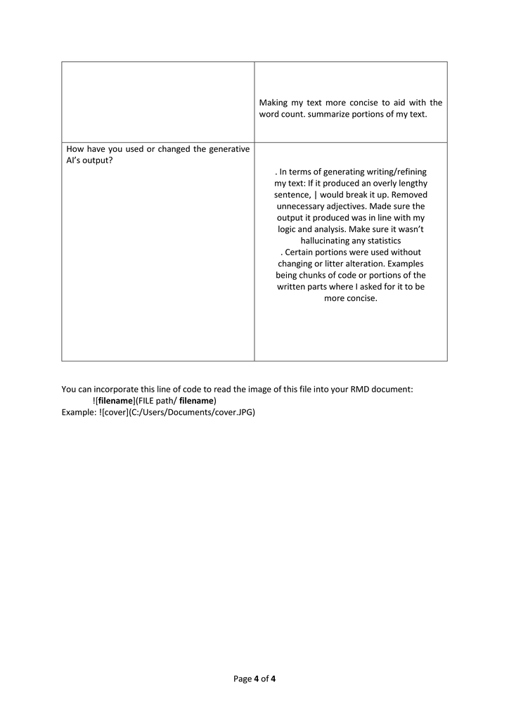

# Abstract

Breast cancer (BC) is a heterogeneous disease with variable prognosis. Molecular subtyping using PAM50 distinguishes Luminal A (LumA) and Luminal B (LumB) tumours, which differ in proliferation, receptor expression, and clinical outcomes. Somatic mutations, particularly in TP53 and PIK3CA, may influence subtype-specific survival. Data from 1,157 Luminal breast cancer patients in the METABRIC cohort were analysed. Differential gene expression between LumA and LumB was assessed using limma, followed by principal component analysis. Mutation frequencies of TP53 and PIK3CA were compared across subtypes, and tumour mutation burden (TMB) was calculated. Overall survival was evaluated using Kaplan-Meier analysis and Cox proportional hazards models, adjusting for clinical covariates. LumB tumours exhibited higher expression of proliferation-associated genes (e.g., CCNA2, BUB1, UBE2C) and partially distinct transcriptional profiles. TP53 mutations were enriched in LumB tumours (111 vs. 80 in LumA), while PIK3CA mutations were more frequent in LumA (387 vs. 159 in LumB). TMB did not differ significantly between subtypes (median 0.1, p = 0.072). Survival analysis revealed that TP53 mutations were associated with poorer outcomes, with TP53-mutated LumA tumours showing unexpectedly low survival. PIK3CA mutations were not independently associated with survival. Multivariable Cox regression confirmed that LumB subtype and TP53 mutation were independently linked to higher hazard of death. TP53 and PIK3CA mutation patterns differ between Luminal subtypes, with TP53 mutations identifying a high-risk subgroup within otherwise favorable LumA tumours. Integrating mutation status with molecular subtype can improve prognostic stratification and inform personalised management in luminal breast cancer. Future research should explore additional driver mutations and co-mutation effects to refine survival prediction models.

# Introduction

Among women globally, breast cancer (BC) remains the most frequently diagnosed cancer (1). As of 2020, approximately 2.3 million new cases were reported worldwide, accounting for 6.9% of cancer-related deaths(1,2). One of the defining characteristics of BC is its heterogeneity, with tumors exhibiting substantial biological and clinical diversity that influences disease progression, treatment response, and prognosis(3,4).

One approach to classify the heterogeneous nature of breast cancer is to use a molecular subtyping technique such as Prediction Analysis of Microarray 50 (PAM50)(5). PAM50 is a 50-gene classifier that stratifies BC based on gene expression patterns (intrinsic subtypes): Luminal A (LumA), Luminal B (LumB), human epidermal growth factor receptor 2 (HER2)-enriched, Basal-like, and Normal-like (5–8). This analysis focuses on LumA and LumB since LumA accounts for 50-60% of all breast cancers and LumB contributes 15-20% (9). LumA is a slow-progressing BC and is characterised by its high expression of progesterone receptors (PR), estrogen receptors (ER), and low proliferation-related genes. In comparison, LumB is more aggressive in development and is distinguished by lower PR and ER expression and high gene expression linked to cell cycle, proliferation, and growth factor receptors(10–14). Since PAM50 subtypes are defined using gene expression, reflecting underlying biological differences, it is broadly used in clinical/research settings, making it appropriate for analysis.

While subtyping by gene expression captures important biological distinctions between BC subtypes, these expression patterns are frequently influenced by genomic alterations such as somatic mutations. Such mutations impact various genes, including those involved with tumor suppression, oncogenesis, and DNA repair. Tumor protein-53 (TP53) and PIK3CA are among the most frequently mutated genes in breast cancer(15,16). TP53 is a tumor-suppressing gene that controls cell division and growth, and safeguards cells from genomic alterations induced by DNA damage by inhibiting proliferation or triggering programmed cell death (apoptosis)(17,18). The PIK3CA gene regulates cell growth and survival via signalling pathways, and mutations in this gene can enhance growth signals, contributing to uncontrolled cell proliferation in cancer(19).

To explore these relationships, this study utilises data from the Molecular Taxonomy of Breast Cancer International Consortium (METABRIC), which comprises comprehensive genomic, transcriptomic, and clinical outcome data from breast tumours (20). Overall survival was selected as the primary outcome because it provides a clinically meaningful measure of prognosis, allowing the potential impact of genomic alterations and mutation patterns to be assessed in relation to patient survival. Accordingly, this study examines how TP53 and PIK3CA mutation patterns vary across LumA and LumB in METABRIC and how these mutations relate to overall survival. Through this exploratory analysis, the aim is to better understand how genomic alterations interact with molecular subtype and clinically relevant characteristics in breast cancer.

# Method

## Data Sources

Data for this study were obtained from a curated subset of the METABRIC cohort. The dataset was accessed via the cBioPortal for Cancer Genomics, and the version used here consisted of cleaned and simplified clinical, mutation, and gene expression data.

### Clinical Data

The clinical dataset comprised information from 2,509 primary breast cancer patients and included demographic variables, treatment information (chemotherapy, hormone therapy, and radiotherapy), receptor status indicators, molecular subtype classifications (PAM50 and integrative clustering), and overall survival outcomes. Numeric variables included age at diagnosis and overall survival time in months.

| Column Name | Description | Measurement |
| --- | --- | --- |
| patient_id | Unique identifier for each individual |  |
| age_at_diagnosis | Individual’s age at diagnosis | Years |
| sex | Individuals Gender | Female, Male |
| menopausal_state | Menopausal status at diagnosis | Pre, Post, Peri, Unknown |
| er_status_ihc | Estrogen receptor (ER) status evaluated by immunohistochemistry (IHC) | Positive, Negative, Unknown |
| her2_status_snp6 | HER2 (ERBB2) amplification status inferred from SNP6 copy-number data | Amplified, Not Amplified, Unknown |
| chemotherapy | If patient received chemotherapy | Yes, No, Unknown |
| hormone_therapy | If patient received endocrine (hormone) therapy | Yes, No, Unknown |
| radiotherapy | If patient received radiotherapy | Yes, No, Unknown |
| pam50_subtype | Breast cancer subtype based on PAM50 gene expression classifier | Luminal A, Luminal B, HER2-enriched, Basal-like, Normal-like |
| intclust_subtype | METABRIC integrative cluster (IntClust) | IntClust 1–IntClust 10 (sometimes 1–10) |
| os_months | Overall survival time | Months |
| os_status | Overall survival event indicator | Deceased, Living |

### Mutation Data

Mutation data were obtained from the METABRIC cohort in Mutation Annotation Format (MAF). This dataset contains annotated tumour sequencing variants across 2,369 samples, including information on mutation classifications (e.g., missense, nonsense, splice-site, and frameshift mutations) and gene-level mutation summaries.

## Preprocessing

### Clinical Data Preprocessing

Clinical data from the METABRIC cohort were imported into R for preprocessing. An initial exploratory inspection was conducted to evaluate dataset dimensions and variable completeness, informing subsequent data-cleansing steps. Missing values were recoded as NA, and rows with missing data were excluded from analysis due to the extent of missingness. The dataset was restricted to LumA and LumB breast cancer subtypes to enable subtype-specific comparisons.

Following these steps, 1,157 samples remained from the initial 2,509 (1,352 rows removed). Relevant categorical clinical variables—including treatment indicators, menopausal status, HER2 status, survival status, and molecular subtype classifications—were converted to factor variables for appropriate statistical analysis. Descriptive summaries were generated to verify that preprocessing steps were applied correctly and that the cleaned dataset was suitable for analysis.

### Gene Expression Data Preprocessing

Tab-delimited gene expression data were imported into R. Based on the Hugo_Symbol annotation, 199 duplicate gene symbols were identified, attributable to multiple probes per gene. These probes were collapsed to a single representative expression value using the median across probes(21). After collapsing duplicate probes, 20,385 gene entries remained from the initial 20,603.

The resulting dataset was converted into a matrix and transposed so that rows represented patients and columns represented genes. Patient identifiers were aligned between the gene expression and clinical datasets using unique patient IDs to assign PAM50 subtype annotations. Of 1,980 expression samples, 1,157 were successfully linked to clinical subtype data, while 823 samples lacking subtype information were excluded to ensure consistency between clinical and transcriptomic datasets for downstream analyses.

### Mutation Data Preprocessing

Following quality control assessment of the mutation data using the maftools package in R, clinical annotation data were processed to extract PAM50 molecular subtypes, which were subsequently merged with the mutation data using sample identifiers to enable subtype-specific analyses. The complete mutation dataset was then stratified based on PAM50 subtypes using the subsetMaf() function, creating two distinct MAF objects representing LumA and LumB tumours for comparative genomic analysis between these clinically relevant breast cancer subtypes.

## Analysis

### Gene Expression Analysis

Differential expression analysis between LumB and LumA subtypes was performed using limma. LumA was set as the reference level, and linear models were fitted to gene expression values, followed by empirical Bayes moderation (22,23). Limma was selected due to its empirical Bayes moderation, which improves variance estimation in high-dimensional microarray data with relatively small sample sizes, increasing statistical power while controlling false discovery rates. P-values were adjusted for multiple testing using the Benjamini–Hochberg method (22,24). Genes with adjusted p-values < 0.05 were considered significantly differentially expressed (23). Only seven rows with missing expression values were identified; these samples were removed, and zero-variance genes were filtered out before PCA.

### Principal Component Analysis (PCA)

Performing PCA on the full expression matrix was considered; however, restricting to significant genes enhanced interpretability by focusing on subtype-driven biological variation rather than global background noise. PCA was performed after centering and scaling the data, and patients were plotted along the first two principal components, coloured by subtype, with 95% confidence ellipses to illustrate clustering.

### Mutation Analysis

Subtype-Specific Mutation Patterns

Mutation data were stratified by subtype to create separate MAF objects for LumA and LumB patients. Subtype-specific mutation frequencies were compared using the mafCompare function to identify genes with statistically significant differences. Genes with p-values below 0.05 were considered to differ between subtypes.

### Tumour Mutation Burden

Tumour mutation burden (TMB), defined as the number of mutations per megabase of coding DNA, was calculated for each patient. TMB was calculated using maftools default coding region length assumptions, enabling standardised comparison across samples. TMB distributions were compared between subtypes using a Wilcoxon rank-sum test and visualised using boxplots.

## Survival Analysis

### Kaplan-Meier Analysis

Overall survival was analysed using Kaplan-Meier estimates, stratified by subtype. Survival time was defined as months from diagnosis to death or last follow-up, with deceased patients coded as events.

# Results

## Cohort Characteristics

The final analytical dataset included 1,157 patients with Luminal breast cancer subtypes: 690 LumA (59.6%) and 467 LumB (40.4%). Patients with LumB tumours were slightly older on average (mean 65.3 years vs. 62.7) and more frequently postmenopausal (89.3% vs. 81.7%). Treatment followed similar patterns across subtypes: hormone therapy and radiotherapy were more common in patients of both subtypes, whereas chemotherapy was least frequent. However, LumB had a larger proportion of individuals receiving treatments across all therapies. HER2 positivity was higher in LumB (25.5% vs. 10.6%), while ER positivity was nearly universal across both subtypes (>97%). These characteristics suggest that LumB tumours present with a more aggressive clinical phenotype and are treated more intensively, consistent with prior literature.

Table 1: Clinical and pathological characteristics of LumA (n = 690) and LumB (n = 467) patients included in the final analytical cohort.

| pam50_subtype | N | Age_mean | Age_sd | Age_median | Age_Q1_Q3 | PreMenopausal_n | PreMenopausal_pct | PostMenopausal_n | PostMenopausal_pct | Chemotherapy_yes | Chemotherapy_pct | HormoneTherapy_yes | HormoneTherapy_pct | Radiotherapy_yes | Radiotherapy_pct | HER2_positive | HER2_pct | ERstatus_pos | ERstatus_pct |
| --- | --- | --- | --- | --- | --- | --- | --- | --- | --- | --- | --- | --- | --- | --- | --- | --- | --- | --- | --- |
| LumA | 690 | 62.7 | 12.5 | 63.23 | 53 - 72.2 | 126 | 18.3% | 564 | 81.7% | 56 | 8.1% | 471 | 68.3% | 376 | 54.5% | 73 | 10.6% | 677 | 98.1% |
| LumB | 467 | 65.3 | 11.4 | 66.48 | 58.9 - 74 | 50 | 10.7% | 417 | 89.3% | 47 | 10.1% | 376 | 80.5% | 297 | 63.6% | 119 | 25.5% | 456 | 97.6% |

## Differential Gene Expression between Luminal Subtypes

Using the preprocessed gene expression dataset (20,385 genes after probe collapsing), differential expression analysis identified a subset of genes upregulated in LumB compared to LumA tumours (adjusted p-value < 0.05). The top 10 differentially expressed genes are summarised in Table 2. These included CCNA2, BUB1, CEP55, RACGAP1, CKAP2L, PTTG1, PTTG3P, CDKN3, UBE2C, and CENPA, all of which exhibited positive log2 fold-change values, indicating higher expression in the LumB subtype.

**Table 2:** Top 10 genes significantly upregulated in Luminal B compared to LumA (adjusted p-value < 0.05), ranked by moderated t-statistic. Positive log2 fold-change (logFC) values indicate higher expression in Luminal B tumours.

Table 2: Top 10 Differentially Expressed Genes between Luminal A and Luminal B

|  | logFC | AveExpr | t | P.Value | adj.P.Val | B |
| --- | --- | --- | --- | --- | --- | --- |
| CCNA2 | 1.087 | -0.239 | 29.458 | 2.302838e-143 | 4.694335e-139 | 316.755 |
| BUB1 | 1.048 | -0.250 | 29.359 | 1.235521e-142 | 1.259305e-138 | 315.082 |
| CEP55 | 1.080 | -0.249 | 29.278 | 4.828968e-142 | 3.281284e-138 | 313.724 |
| RACGAP1 | 1.257 | -0.098 | 29.078 | 1.443773e-140 | 7.357827e-137 | 310.341 |
| CKAP2L | 1.121 | -0.205 | 28.704 | 8.117823e-138 | 3.309636e-134 | 304.035 |
| PTTG1 | 1.192 | -0.220 | 28.605 | 4.347101e-137 | 1.270534e-133 | 302.365 |
| PTTG3P | 1.195 | -0.193 | 28.604 | 4.362884e-137 | 1.270534e-133 | 302.361 |
| CDKN3 | 1.219 | -0.149 | 28.125 | 1.427120e-133 | 3.636479e-130 | 294.302 |
| UBE2C | 1.134 | -0.203 | 27.557 | 2.016673e-129 | 4.567765e-126 | 284.786 |
| CENPA | 0.957 | -0.283 | 27.426 | 1.785445e-128 | 3.639630e-125 | 282.614 |

## Principal Component Analysis of Gene Expression

**Figure 1:** PCA of Luminal A and Luminal B tumours using significantly differentially expressed genes. PC1 and PC2 explain 9.7% and 6.7% of total variance, respectively. Points represent individual tumours, with ellipses indicating 95% confidence regions for each subtype.

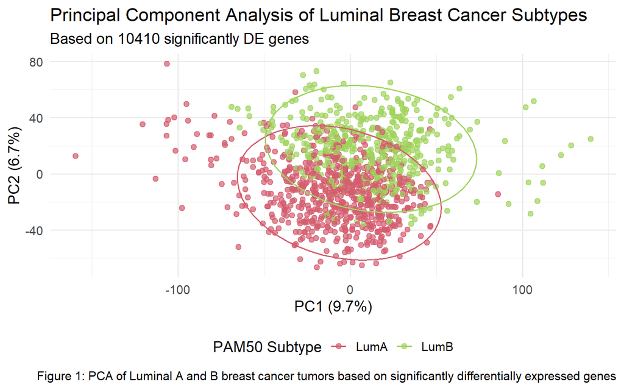

## Subtype-Specific Mutation Analysis

Mutation analysis was conducted on 444 LumB and 661 LumA tumour samples to identify differences in the prevalence of key somatic alterations. Among the evaluated genes, PIK3CA, TP53, and MAP3K1 showed strong differences in mutation frequency between subtypes (p < 0.001), with PIK3CA mutations more frequent in LumA tumours (387 vs. 159 in LumB), while TP53 mutations were more frequent in LumB tumours (111 vs. 80 in LumA). CBFB and DNAH11 displayed moderate importance (p < 0.01), and the remaining genes—including AKAP9, PPP2R2A, USP28, LAMB3, GATA3, DTWD2, and ARID1A—were marginally important (p < 0.05).

Odds ratio (OR) analysis supported these trends, with values greater than 1 indicating higher mutation frequency in LumA tumours, and values less than 1 indicating higher frequency in LumB tumours. Despite subtype-specific differences in individual gene mutations, tumour mutation burden (TMB) was comparable between groups. Median TMB values were 0.1 mutations per megabase in both LumA and LumB tumours (mean 0.111 vs. 0.108, respectively). As shown in Figure 3, the boxplots demonstrate nearly identical interquartile ranges and substantial overlap in overall distribution between subtypes. Although LumB tumours exhibited a slightly greater number of high-value outliers, the central tendency and spread were highly similar. Consistent with this visual pattern, the difference in TMB between LumA and LumB tumours did not reach statistical significance (Wilcoxon rank-sum test, p = 0.072), suggesting that global mutation burden does not substantially distinguish these luminal subtypes.

**Figure 2:** Forest plot comparing mutation frequencies between Luminal A (n = 661) and Luminal B (n = 444) tumours. Odds ratios (OR) with 95% confidence intervals are shown; OR > 1 indicates higher mutation frequency in LumA, and OR < 1 indicates higher frequency in LumB. Significant differences (p < 0.05) highlight enrichment of PIK3CA in LumA and TP53 in LumB tumours.

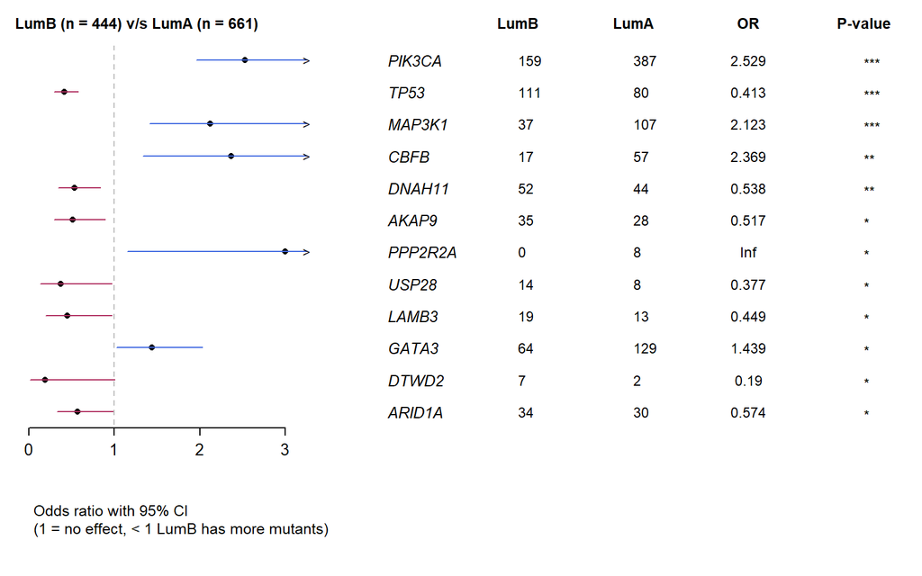

**Figure 3:** Distribution of tumour mutation burden (mutations per megabase) in LumA and LumB tumours. Boxplots show median and interquartile range, with individual outliers displayed. TMB distributions are highly similar between subtypes (Wilcoxon p = 0.072).

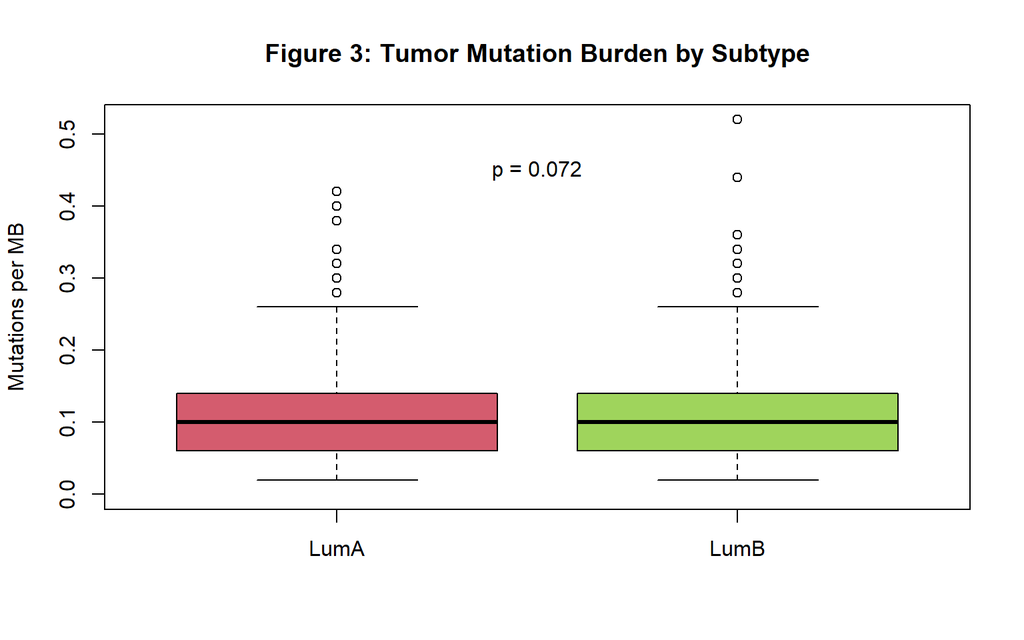

## Kaplan–Meier Survival Analysis

In the TP53-stratified survival analysis (Figure 4), LumA tumours harbouring TP53 mutations demonstrated the poorest overall survival, with the survival curve consistently remaining below all other groups throughout follow-up. LumB TP53-mutant tumours also showed reduced survival relative to wild-type counterparts, though their survival probability remained higher than that observed in LumA TP53-mutant tumours. Wild-type groups in both subtypes exhibited comparatively improved survival.

Similarly, in the PIK3CA-stratified analysis (Figure 5), LumA tumours with PIK3CA mutations demonstrated the lowest survival probability across the observed time period. Although differences between groups were less pronounced than in the TP53 analysis, the LumA mutant group remained the bottom-most survival curve, while wild-type groups showed comparatively better outcomes.

**Figure 4:** Kaplan–Meier overall survival curves stratified by TP53 mutation status within LumA and LumB subtypes. Curves represent wild-type (WT) and mutant (Mut) groups for each subtype, with numbers at risk shown below the plot. Differences between groups were statistically significant (log-rank test, p < 0.0001).

[figure not shown]

**Figure 5:** Kaplan–Meier overall survival curves stratified by PIK3CA mutation status within Luminal A and Luminal B subtypes. Wild-type (WT) and mutant (Mut) groups are shown for each subtype, with corresponding numbers at risk displayed beneath the plot. Survival differences across groups were statistically significant (log-rank test, p < 0.0001).

[figure not shown]

## Cox Proportional Hazards Regression Analysis

### Unadjusted Model

In the unadjusted Cox proportional hazards model, LumB subtype was significantly associated with worse overall survival compared to LumA (HR = 1.59, 95% CI: 1.36–1.86, p < 0.001).

TP53 wild-type status was associated with improved survival relative to TP53-mutant tumours (HR = 0.76, 95% CI: 0.63–0.93, p = 0.007).

PIK3CA wild-type status was not strongly associated with survival (HR = 0.88, 95% CI: 0.75–1.02, p = 0.095).

### Adjusted Model

After adjusting for molecular subtype and treatment variables, LumB subtype remained independently associated with poorer survival (HR = 1.52, 95% CI: 1.30–1.78, p < 0.001).

TP53 wild-type status also remained strongly associated with improved survival (HR = 0.79, 95% CI: 0.65–0.96, p = 0.016).

PIK3CA wild-type status remained non-significant following adjustment (HR = 0.87, 95% CI: 0.74–1.01, p = 0.071).

Among treatment variables, hormone therapy was strongly associated with survival (p < 0.001), whereas chemotherapy was not strongly associated with outcome (p = 0.271).

Table 3: Unadjusted Cox proportional hazards model for overall survival.

| term | estimate | std.error | statistic | p.value | conf.low | conf.high |
| --- | --- | --- | --- | --- | --- | --- |
| pam50_subtypeLumB | 1.5920 | 0.0805 | 5.7793 | 0.0000 | 1.3597 | 1.8639 |
| TP53_statusWild-type | 0.7649 | 0.0995 | -2.6928 | 0.0071 | 0.6293 | 0.9296 |
| PIK3CA_statusWild-type | 0.8758 | 0.0793 | -1.6710 | 0.0947 | 0.7497 | 1.0232 |

Table 4: Multivariable Cox proportional hazards model adjusting for subtype and treatment variables.

| term | estimate | std.error | statistic | p.value | conf.low | conf.high |
| --- | --- | --- | --- | --- | --- | --- |
| pam50_subtypeLumB | 1.5204 | 0.0809 | 5.1777 | 0.0000 | 1.2974 | 1.7818 |
| TP53_statusWild-type | 0.7863 | 0.1000 | -2.4057 | 0.0161 | 0.6464 | 0.9564 |
| PIK3CA_statusWild-type | 0.8664 | 0.0792 | -1.8089 | 0.0705 | 0.7418 | 1.0120 |
| chemotherapyYES | 1.1738 | 0.1454 | 1.1017 | 0.2706 | 0.8827 | 1.5609 |
| hormone_therapyYES | 1.4037 | 0.0903 | 3.7542 | 0.0002 | 1.1759 | 1.6755 |

## Discussion

This study investigated differences in TP53 and PIK3CA mutation patterns between LumA and LumB tumours in METABRIC and examined how these mutations relate to overall survival. The analysis revealed that TP53 mutations were enriched in LumB tumours, whereas PIK3CA mutations were more frequent in Luminal A, although total mutation burden did not differ significantly between subtypes. Both mutations were associated with differential overall survival outcomes depending on subtype.

Gene expression differences stratified by subtype were consistent with established biological characteristics in Luminal breast cancer tumours. PCA revealed noticeable clustering of LumA and LumB tumours, though the clusters overlapped, consistent with previous transcriptomic analyses demonstrating shared expression patterns between luminal subtypes (6,12,25). The partial separation indicates meaningful biological variation that differentiates these subtypes(26–29). Differentially expressed genes in LumB, including CCNA2, BUB1, and UBE2C, are key regulators of mitosis and the cell cycle, reflecting the higher proliferative activity typical of LumB tumours. This aligns with prior studies linking elevated proliferation signatures to poorer prognosis in LumB breast cancers, emphasising that molecular profiling can aid in differentiating between BC tumour types and understanding their molecular drivers(30–32).

There was evident subtype-specific enrichment in mutation patterns from the METABRIC cohort. TP53 mutations were observed more frequently in LumB tumours, consistent with prior genomic characterisations of breast cancer subtypes, which report higher TP53 mutation rates in more proliferative luminal and basal-like tumours, supporting the biological aggressiveness observed in LumB disease (33,34). Conversely, PIK3CA mutations were enriched in LumA tumours, reflecting their prevalence in less aggressive, hormone receptor-positive disease, as reported in prior genomic analyses (7,35,36). Additional subtype-specific patterns included enrichment of MAP3K1 and CBFB mutations in Luminal A, and DNAH11, AKAP9, and USP28 mutations in LumB. According to our data, PPP2R2A mutations were observed in a small number of LumA cases, contrary to previous studies indicating higher prevalence in LumB. In this analysis, no PPP2R2A mutations were observed in LumB, warranting careful interpretation. Overall, the similar TMB between LumA and B tumours (median 0.1, p = 0.072) suggests that global mutation load does not account for the observed survival differences, reinforcing the role of specific driver mutations such as TP53 and PIK3CA in defining prognostic outcomes.

Limitations of this study include the representativeness of the METABRIC cohort, which primarily comprises patients from the UK and Canada, potentially limiting generalisability to more diverse populations. Another limitation is that this study focused solely on TP53 and PIK3CA; other genomic alterations could impact survival but were not included. Furthermore, small mutation counts in some subgroups, particularly TP53 mutations in Luminal A, may reduce the stability of estimates. Future research could include other driver mutations or copy number variations beyond TP53 and PIK3CA, examine co-mutation patterns between TP53 and PIK3CA and their combined effect on survival, and incorporate additional patient characteristics, such as menopausal status.

## Conclusion

This study aimed to investigate how TP53 and PIK3CA mutation patterns differ between LumA and LumB breast cancers in METABRIC and how these mutations relate to overall survival. Our analysis revealed that TP53 mutations were enriched in LumB tumours and associated with a higher risk of death, while PIK3CA mutations were more common in LumA tumours but did not independently influence survival. Notably, TP53 mutations in LumA tumours identified a subgroup with unexpectedly poor prognosis, demonstrating that mutation status can provide additional prognostic insight beyond molecular subtype alone. These findings emphasise that integrating genomic alterations with subtype classification can improve risk stratification and inform personalised management strategies in luminal breast cancer. Future studies should explore additional driver mutations and co-mutation patterns to further refine prognostic models and support clinical decision-making.

# Supplementary

```
##
## === Clinical Data Processing Summary ===
```

```
## Initial samples: 2509
```

```
## Final samples (LumA/LumB only): 1157
```

```
## Samples removed: 1352 (53.9%)
```

```
##
## === Expression Data Processing Summary ===
```

```
## Duplicate genes before collapsing: 199
```

```
## Genes after collapsing: 20385
```

```
## Samples matched to clinical data: 1157
```

```
## Samples removed (no subtype): 823
```

```
##
## === Mutation Data Summary ===
```

```
## Total samples with mutation data: 2369
```

```
## Total genes mutated: 173
```

```
## Median mutations per sample: 5
```

```
##
## === Differential Expression Results ===
```

```
## Total genes analyzed: 20385
```

```
## Significant genes (FDR < 0.05): 10410
```

```
## Genes upregulated in LumB (logFC > 0): 5685
```

```
## Genes downregulated in LumB (logFC < 0): 4725
```

```
## Samples with missing values: 7
```

```
## Samples removed due to missing values: 7
```

```
## Remaining NA values after cleaning: 0
```

```
## Genes with zero variance removed: 0
```

```
## Remaining NA values after cleaning: 0
```

```
## Samples after na.omit: 1150
```

```
## Luminal A tumor mutation burden (median): 0.1
```

```
## Luminal B tumor mutation burden (median): 0.1
```

```
## Luminal A tumor mutation burden (mean): 0.11059
```

```
## Luminal B tumor mutation burden (mean): 0.1079279
```

```
## === TP53 Mutation Counts by Luminal Subtype ===
```

```
## # A tibble: 4 × 3
##   pam50_subtype TP53_status     N
##   <fct>         <chr>       <int>
## 1 LumA          Mutated        80
## 2 LumA          Wild-type     610
## 3 LumB          Mutated       111
## 4 LumB          Wild-type     356
```

```
##
## === PIK3CA Mutation Counts by Luminal Subtype ===
```

```
## # A tibble: 4 × 3
##   pam50_subtype PIK3CA_status     N
##   <fct>         <chr>         <int>
## 1 LumA          Mutated         387
## 2 LumA          Wild-type       303
## 3 LumB          Mutated         159
## 4 LumB          Wild-type       308
```

```
##    patient_id age_at_diagnosis    sex menopausal_state er_status_ihc
##        <char>            <num> <char>           <fctr>        <fctr>
## 1:    MB-0002            43.19 Female              Pre      Positive
## 2:    MB-0005            48.87 Female              Pre      Positive
## 3:    MB-0006            47.68 Female              Pre      Positive
## 4:    MB-0008            76.97 Female             Post      Positive
## 5:    MB-0010            78.77 Female             Post      Positive
## 6:    MB-0014            56.45 Female             Post      Positive
##    her2_status_snp6 chemotherapy hormone_therapy radiotherapy pam50_subtype
##              <fctr>       <fctr>          <fctr>       <fctr>        <fctr>
## 1:          NEUTRAL           NO             YES          YES          LumA
## 2:          NEUTRAL          YES             YES           NO          LumB
## 3:          NEUTRAL          YES             YES          YES          LumB
## 4:          NEUTRAL          YES             YES          YES          LumB
## 5:          NEUTRAL           NO             YES          YES          LumB
## 6:             LOSS          YES             YES          YES          LumB
##    intclust_subtype os_months  os_status
##              <fctr>     <num>     <fctr>
## 1:             4ER+  84.63333   0:LIVING
## 2:                3 163.70000 1:DECEASED
## 3:                9 164.93333   0:LIVING
## 4:                9  41.36667 1:DECEASED
## 5:                7   7.80000 1:DECEASED
## 6:                3 164.33333   0:LIVING
```

# References

1.

Siegel RL Sung H Ferlay J. Global cancer statistics 2020: GLOBOCAN estimates of incidence and mortality worldwide for 36 cancers in 185 countries. CA Cancer J Clin. 2021;71(3):209–49.

2.

Zhang T Xu S Liu Y. The global, regional, and national burden and trends of breast cancer from 1990 to 2019: Results from the global burden of disease study 2019. Front Oncol. 2021;11:689562.

3.

National Cancer Institute. Tumor heterogeneity [Internet]. NCI Dictionary of Cancer Terms; 2026. Available from: https://www.cancer.gov/publications/dictionaries/cancer-terms/def/tumor-heterogeneity

4.

Peleaşa TM Popa MT Noditi A. Breast cancer: A heterogeneous pathology. Prognostic and predictive factors – a narrative review. Chirurgia. 2025;120(1):32–47.

5.

Cheang MCU Parker JS Mullins M. Supervised risk predictor of breast cancer based on intrinsic subtypes. J Clin Oncol. 2009;27(8):1160–7.

6.

Eisen MB Perou CM Sørlie T. Molecular portraits of human breast tumours. Nature. 2000;406(6797):747–52.

7.

et al. Cancer Genome Atlas Network. Comprehensive molecular portraits of human breast tumors. Nature. 2012;490(7418):61–70.

8.

Wang J Kensler KH Sankar VN. PAM50 molecular intrinsic subtypes in the nurses’ health study cohorts. Cancer Epidemiol Biomarkers Prev. 2019;28(4):798–806.

9.

Barutca S Yersal O. Biological subtypes of breast cancer: Prognostic and therapeutic implications. World J Clin Oncol. 2014;5(3):412–24.

10.

Haider I Henry NL Shah PD. Cancer of the breast. In, editorKastan MB Niederhuber JE Armitage JO. Abeloff’s clinical oncology, 6th edition. Philadelphia: Elsevier; 2020. p. 1560–1603.e12.

11.

Bai Z Dai X Li T. Breast cancer intrinsic subtype classification, clinical use and future trends. Am J Cancer Res. 2015;5(10):2929–43.

12.

Adamo B Prat A Pineda E. Clinical implications of the intrinsic molecular subtypes of breast cancer. Breast. 2015;24:S26–35.

13.

Bozovic-Spasojevic I Ades F Zardavas D. Luminal b breast cancer: Molecular characterization, clinical management, and future perspectives. J Clin Oncol. 2014;32(25):2794–803.

14.

Keren-Khadmy N Sinberger LA Zahavi T. Refining prognostic tools for luminal breast cancer: Genetic insights and comprehensive analysis. ESMO Open. 2025;10(5):105080.

15.

Tadi P Miles B. Genetics, somatic mutation. In: StatPearls. Treasure Island (FL): StatPearls Publishing; 2025.

16.

Olszewski P Kostecka A Nowikiewicz T. High prevalence of somatic PIK3CA and TP53 pathogenic variants in the normal mammary gland tissue of sporadic breast cancer patients revealed by duplex sequencing. NPJ Breast Cancer. 2022;8(1):76.

17.

Hainaut P Olivier M Hollstein M. TP53 mutations in human cancers: Origins, consequences, and clinical use. Cold Spring Harb Perspect Biol. 2010;2(1):a001008.

18.

Punie K Blondeaux E Arecco L. Germline TP53 pathogenic variants and breast cancer: A narrative review. Cancer Treat Rev. 2023;114:102522.

19.

Vogt PK Zhao L. Class i PI3K in oncogenic cellular transformation. Oncogene. 2008;27(41):5486–96.

20.

Chin SF Curtis C Shah SP. The genomic and transcriptomic architecture of 2,000 breast tumours reveals novel subgroups. Nature. 2012;486(7403):346–52.

21.

Su SL Chou HL Yao CT. Gene expression profiling of breast cancer survivability by pooled cDNA microarray analysis using logistic regression, artificial neural networks and decision trees. BMC Bioinformatics. 2013;14(1):100.

22.

Häkkinen J Bjørklund SS Aure MR. Subtype and cell type specific expression of lncRNAs provide insight into breast cancer. Commun Biol. 2022;5(1):834.

23.

Wu DI Ritchie ME Phipson B. Limma powers differential expression analyses for RNA-sequencing and microarray studies. Nucleic Acids Res. 2015;43(7):e47.

24.

Hochberg Y Benjamini Y. Controlling the false discovery rate: A practical and powerful approach to multiple testing. J R Stat Soc B. 1995;57:289–300.

25.

Martín M Prat A Cheang MCU. Prognostic significance of progesterone receptor–positive tumor cells within immunohistochemically defined luminal a breast cancer. J Clin Oncol. 2013;31(2):203–9.

26.

Tibshirani R Sørlie T Perou CM. Gene expression patterns of breast carcinomas distinguish tumor subclasses with clinical implications. Proc Natl Acad Sci U S A. 2001;98(19):10869–74.

27.

Voduc D Cheang MCU Chia SK. Ki67 index, HER2 status, and prognosis of patients with luminal b breast cancer. JNCI J Natl Cancer Inst. 2009;101(10):736–50.

28.

Oh DS Hu Z Fan C. The molecular portraits of breast tumors are conserved across microarray platforms. BMC Genomics. 2006;7(1):96.

29.

Van De Rijn M Perou CM Jeffrey SS. Distinctive gene expression patterns in human mammary epithelial cells and breast cancers. Proc Natl Acad Sci U S A. 1999;96(16):9212–7.

30.

National Center for Biotechnology Information (NCBI). CCNA2 cyclin A2 [homo sapiens (human)] [Internet]. National Library of Medicine, National Institutes of Health. Available from: https://www.ncbi.nlm.nih.gov/gene/890

31.

National Center for Biotechnology Information (NCBI). BUB1 mitotic checkpoint serine/threonine kinase [homo sapiens (human)] [Internet]. National Library of Medicine, National Institutes of Health. Available from: https://www.ncbi.nlm.nih.gov/datasets/gene/699/

32.

National Center for Biotechnology Information (NCBI). PIK3CA phosphatidylinositol-4,5-bisphosphate 3-kinase catalytic subunit alpha [homo sapiens (human)] [Internet]. National Library of Medicine, National Institutes of Health. Available from: https://www.ncbi.nlm.nih.gov/datasets/gene/11065/

33.

Sørlie T. Molecular portraits of breast cancer: Tumour subtypes as distinct disease entities. Eur J Cancer. 2004;40(18):2667–75.

34.

Wittmer E Dumay A Feugeas JP. Distinct tumor protein p53 mutants in breast cancer subgroups. Int J Cancer. 2013;132(5):1227–31.

35.

Cleveland Clinic. Luminal a breast cancer [Internet]. Cleveland Clinic; 2024. Available from: https://my.clevelandclinic.org/health/diseases/luminal-a-breast-cancer

36.

Mayer IA Nixon MJ Formisano L. PIK3CA and MAP3K1 alterations imply luminal a status and are associated with clinical benefit from pan-PI3K inhibitor buparlisib and letrozole in ER+ metastatic breast cancer. NPJ Breast Cancer. 2019;5(1):31.